🏠 Inicio del curso | 📈 Simulación del precio de una acción (movimiento browniano)

# Simulación del precio de una acción usando movimientos Brownianos

La simulación de los precios de las acciones juega un papel crucial en las valoración de activos. Debido a la aleatoriedad en el movimiento de los precios, estas simulaciones se apoyan en **ecuaciones diferenciales estocásticas (SDE)**. Un proceso estocástico se dice que sigue un **movimiento geométrico browniano (GBM)** cuando satisface la siguiente estructura diferencial:

$$ d S_t = \mu S_t dt + \sigma S_t dW_t $$

Donde:

- $S_t$ es el precio de la accion.
- $\mu$ Es el coeficiente de deriva. Puede ser el retorno promedio en un periodo dado o un retorno esperado.
- $\sigma$ Es el coeficiente de difusión. Es decir, la volatilidad de la deriva.
- $W_t$ es un movimiento browniano.
- $d$ Simboliza el cambio de una variable a partir de un cambio en el tiempo. $dt$ es el cambio en el tiempo.

No vamos a profundizar en las propiedades de los movimiento brownianos. Es suficiente con decir que los incrementos en un movimiento browniano se calculan como el producto de una distribución normal estándar $(Z \sim N(0,1))$ y la raíz cuadrada del cambio en el tiempo $(\sqrt{t_{i+1} - t_i})$. Esto es lo mismo que decir que los incrementos vienen de una normal $(0,t)$ $(dW_t \sim N(\mu = 0, \sigma^2 = t))$.

El camino browniano es la suma acumulada de los incrementos.

La solución para la ecuación diferencial que hemos visto antes es:

$$ S(t) = S_0 e^{{\left (\mu - \frac{\sigma^2}{2} \right )t + \sigma W_t}} $$

Donde $S_0$ es el precio inicial de la acción.

Ahora bien, para las simulaciones, vamos a emplear una version discreta de la ecuación diferencia (la cual se conoce como ecuación en diferencia):

$$ S(t_{i+1}) = S(t_i) \exp{\left (\left (\mu - \frac{\sigma^2}{2} \right ) (t_{i+1} - t_i) + \sigma \sqrt{t_{i+1} - t_i} Z_{i+1} \right )} $$

Donde $Z_i \sim N(0,1)$ y $i = 0,1, \dots, T-1$ es el indice temporal.

Teniendo en cuenta esta información vamos a simular los precios diarios durante un mes de la acción de JPMorgan Chase & Co., usando los datos desde enero de 2024, para simular los posibles caminos del precio de la acción.

```python
# Importamos las librerías necesarias

import numpy as np
import pandas as pd
import yfinance as yf
import matplotlib.pyplot as plt
```

```python
df = yf.download("JPM",
                 start="2024-01-01",
                 end="",
                 auto_adjust=False)
df
```

```
[*********************100%***********************]  1 of 1 completed
```

| Price Ticker Date | Adj Close JPM | Close JPM | High JPM | Low JPM | Open JPM | Volume JPM |
| --- | --- | --- | --- | --- | --- | --- |
| 2024-01-02 | 161.472717 | 172.080002 | 172.169998 | 168.910004 | 169.089996 | 9977400 |
| 2024-01-03 | 160.768921 | 171.330002 | 172.039993 | 170.369995 | 171.860001 | 9852300 |
| 2024-01-04 | 161.835846 | 171.410004 | 173.350006 | 170.539993 | 170.639999 | 11972500 |
| 2024-01-05 | 162.647797 | 172.270004 | 173.380005 | 171.470001 | 171.470001 | 10066000 |
| 2024-01-08 | 162.411774 | 172.020004 | 172.360001 | 169.490005 | 172.020004 | 11229900 |
| ... | ... | ... | ... | ... | ... | ... |
| 2026-10-28 | 339.299988 | 339.299988 | 340.880005 | 335.170013 | 337.380005 | 5221500 |
| 2026-10-29 | 343.579987 | 343.579987 | 345.750000 | 342.350006 | 344.510010 | 5806400 |
| 2026-10-30 | 337.040009 | 337.040009 | 345.290009 | 335.119995 | 345.290009 | 7904700 |
| 2026-11-02 | 340.579987 | 340.579987 | 342.429993 | 339.920013 | 340.940002 | 6014700 |
| 2026-11-03 | 337.980011 | 337.980011 | 340.750000 | 335.885010 | 340.000000 | 6520491 |

713 rows × 6 columns

Calculemos los retornos diarios de la acción. Lo haremos discretos teniendo en cuenta la forma en la que realizaremos la simulación.

```python
retornos = df["Adj Close"].pct_change().dropna()
```

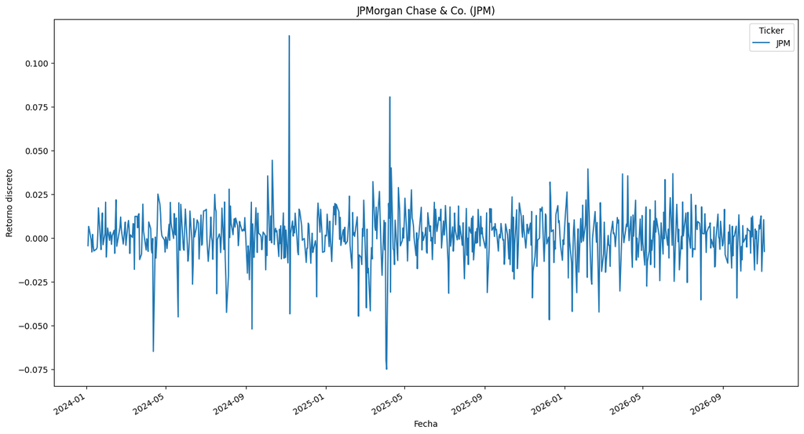

```python
retornos.plot(title="JPMorgan Chase & Co. (JPM)",
              xlabel="Fecha",
              ylabel="Retorno discreto",
              figsize=(16,9))
plt.show()
```

Ahora vamos a dividir los datos en datos de entrenamiento y datos de prueba. Queremos dejar la información del ultimo mes como información de prueba, para ver como se ajusta nuestra simulación a los datos reales.

```python
# Vamos a usar los datos del ultimo mes como conjunto de prueba

train = retornos[:"2026-09-29"]
test = retornos["2026-09-30":]
```

Ahora especifiquemos los parametros de la simulacion:

```python
T = len(test) # Horizonte de la simulación
N = len(test) # Número de pasos en la simulación (puede ser igual a T si queremos simular día a día)
S_0 = df.loc[train.index[-1], "Adj Close"].iloc[0] # Precio inicial de la acción en la simulación
N_SIM = 100 # Número de simulaciones a realizar
mu = train.mean().iloc[0] # Media de los retornos (deriva)
sigma = train.std().iloc[0] # Desviación estándar de los retornos (volatilidad)
```

Ahora vamos a construir la función que emplearemos para crear las simulaciones.

```python
def simulate_gbm(s_0, mu, sigma, n_sims, T, N, start, index, random_seed=42):
    np.random.seed(random_seed)
    dt = T/N # Es el cambio en el tiempo
    dW = np.random.normal(loc = 0, scale=np.sqrt(dt), size=(N, n_sims))
    W = np.cumsum(dW, axis=0)
    time_step = np.linspace(start = dt, stop = T, num = N)
    time_steps = np.broadcast_to(time_step, (n_sims, N)).transpose()
    S_t = (
        s_0 * np.exp((mu - 0.5 * sigma**2) * time_steps + sigma * W)
    )
    S_t = np.insert(S_t, 0, s_0, axis=0)
    S_t = pd.DataFrame(S_t, index = start.union(index))

    return S_t
```

Usando la nueva función, vamos a crear una base de datos con las diferentes simulaciones que vamos a tener del precio de la acción de JPM.

```python
simulacion = simulate_gbm(s_0 = S_0,
                          mu = mu,
                          sigma = sigma,
                          n_sims = N_SIM,
                          T = T,
                          N = N,
                          start = train.index[-1:],
                          index = test.index)
```